# Molecular Marker Assisted Plant Breeding

Relateness, Population Structure and Cofounders

Felipe Ferrão

University of Florida

**Objectives:**

- 60 minutes of hands-on
- Introduction to statistical power in GWAS
- Running simple simulations in R

**Extra information**

- [HOS 6236 – Website](https://lfelipe-ferrao.github.io/class/mas/)
- About the [author](https://lfelipe-ferrao.github.io/)
- About the [UF/IFAS Plant Breeding](https://programs.ifas.ufl.edu/plant-breeding/)

# Introduction

Genome-wide association studies (GWAS) have become a powerful approach for identifying genetic variants associated with complex traits in natural and breeding populations. Unlike traditional QTL mapping, which relies on controlled biparental populations with limited genetic diversity, GWAS leverages the natural variation found in diverse panels of individuals. This diversity increases the resolution of mapping and enables the discovery of variants that may not segregate in simpler populations. However, it also introduces a set of new challenges — most notably, the risk of detecting false-positive associations due to population structure and relatedness among individuals.

One of the central goals in GWAS is to accurately pinpoint causal variants or genes that are directly involved in trait variation. However, individuals can share ancestry or population stratification and create long-range correlations between genetic markers and phenotypes. This means that **a variant may appear to be associated with a trait not because it has a biological effect, but simply because it is more common in a particular subpopulation** that also has different trait values for unrelated reasons (e.g., geography, breeding history, selection).

This is one of the main source of **spurious** associations reported in GWA, and our main goal is to answer the question: **How can we distinguish truly causal variants from those that are associated with the trait due to confounding factors like population structure or relatedness in GWAS?**

## Why Relatedness might be a problem?

In structured or admixed populations, certain alleles may be more frequent in one subgroup than another. If the phenotype also varies across these groups — even due to non-genetic factors like environment — spurious associations can occur between markers and traits. This can lead to the false discovery of genetic loci that have no causal effect, undermining the biological interpretation of GWAS results and potentially leading research in the wrong direction.

Additionally, individuals within a population are often related, meaning they share a proportion of their genome identical-by-descent (IBD). This relatedness also induces correlations in both genotypes and phenotypes that, if not accounted for, can inflate test statistics and increase the number of false positives.

There are two main sources of confounding in GWAS:

**Population Structure**

- Caused by ancestry differences across individuals or subpopulations.
- Leads to systematic allele frequency differences across groups.
- Example: comparing individuals from two different breeding programs or geographical regions.

**Cryptic Relatedness (Kinship)**

- Even within a seemingly homogeneous population, related individuals share genetic background that can bias results.
- Example: siblings or distant cousins sharing both genotypes and traits.

To address these issues, modern GWAS models incorporate corrections for population structure and relatedness. Two common strategies are:

- Principal Component Analysis (PCA): Used to summarize major axes of genetic variation and include them as covariates in the GWAS model to adjust for structure.
- Linear Mixed Models (LMMs): Include a random effect that models the genetic relatedness between individuals using a kinship matrix. This allows the model to control for background polygenic effects and shared ancestry.

These methods greatly reduce the risk of false positives and improve the ability to identify true causal variants by ensuring that associations reflect genuine biological relationships, rather than confounding by structure.

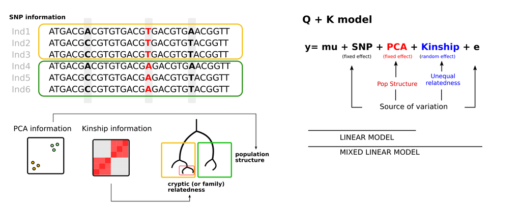

Cryptic Relatedness vs. Population structure effects. Both source of variantions can create false positive in GWAS analyses and therefore should be corrected using linear mixed models

## How to diagnostic my GWAS results?

### The p.value distribution

P-values have a well-understood theoretical distribution under the null hypothesis of no association or effect. Specifically, when there is truly no relationship between the tested variable (e.g., a genetic marker) and the outcome (e.g., a phenotype), the resulting p-values are expected to follow a **uniform distribution between 0 and 1** – i.e, under the null all p-values are equally likely, and any given p-value (e.g., 0.01 or 0.99) should occur with the same probability.

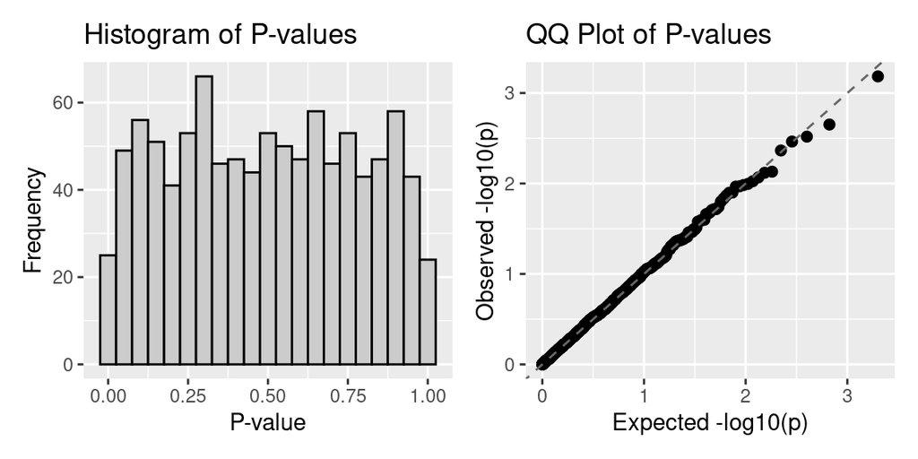

```r
# Load required libraries
library(ggplot2)
library(patchwork)  # for side-by-side plots

# Simulate null data
set.seed(39)
n <- 100     # individuals
p <- 1000    # SNPs
f <- 0.3     # MAF
X <- matrix(rbinom(n * p, 2, f), nrow = n, ncol = p)
y <- rnorm(n)

# Linear regression for each SNP
lm.res <- apply(X, 2, function(x) summary(lm(y ~ x))$coefficients[2, ])
pvals <- as.numeric(lm.res["Pr(>|t|)", ])

# Create data frame
pval_df <- data.frame(PValue = pvals)

# Histogram of p-values
hist_plot <- ggplot(pval_df, aes(x = PValue)) +
  geom_histogram(binwidth = 0.05, fill = "gray80", color = "black") +
  labs(title = "Histogram of P-values", x = "P-value", y = "Frequency")
# QQ plot of p-values
# Expected uniform distribution
expected <- -log10(ppoints(length(pvals)))
observed <- -log10(sort(pvals))
qq_df <- data.frame(Expected = expected, Observed = observed)

qq_plot <- ggplot(qq_df, aes(x = Expected, y = Observed)) +
  geom_point(size = 2) +
  geom_abline(intercept = 0, slope = 1, linetype = "dashed", color = "gray40") +
  labs(title = "QQ Plot of P-values", x = "Expected -log10(p)", y = "Observed -log10(p)")


# Combine plots side by side
hist_plot + qq_plot
```

**Behind of the QQ-plot**

Under the null hypothesis (no true associations), the p-values should follow a Uniform(0, 1) distribution. A “regular”QQ-plot” should have the dots following the expected line, deviation from this expected distribution can tell us about important factors in the GWAS analysis.

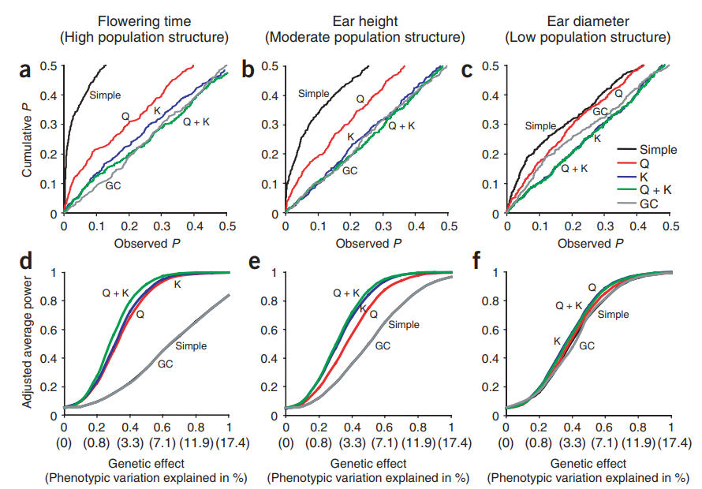

Another nice explanation about the distribution and analysis of the p.value are reported in this [blog](http://varianceexplained.org/statistics/interpreting-pvalue-histogram/) by David Robison, who presents some nice explanations about p.value distribution. Make a histogram of the p-values (or a QQ-plot) is an excellent alternative.

## What can creat population structure?

Population structure arises when a population divides into subgroups that do not randomly mate with each other. In plants, structure can be caused by many sources discussed during population genetic courses.

Below we show an example of genetic drift in a simulated example:

- We simulated a group of 100 individuals in the same area.
- Half migrated to a new area where sub-populations do not have any contact with each other and no genetic exchange in the following generations.
- The figure shows eight potential paths, across multiple generations, for our sub-populations that started to exchange alleles for a given allele.

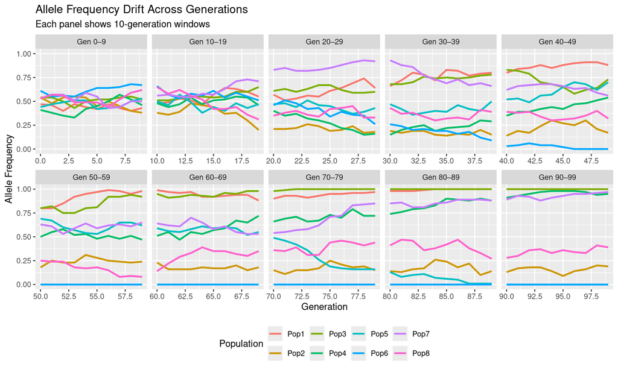

## The Blueberry Example

To illustrate the concept of population structure, let’s consider an analogy from the **blueberry breeding program at the University of Florida**. This program actively combines breeding and pre-breeding efforts to develop improved cultivars.

Each year, during Stage I of the recurrent selection scheme, a high-density nursery is established, where approximately 20,000 seedlings are planted in a single field. The majority of these seedlings result from controlled crosses, specifically designed to enhance agronomic and fruit quality traits such as yield, shelf life, and flavor.

However, what makes this field particularly interesting is the integration of pre-breeding material. Roughly one-quarter of the field is allocated to **pre-breeding**, where wild blueberry species or exotic germplasm—originating from diverse backgrounds—are planted for field evaluation and used as future introgression into the **breeding** pipeline.

In the example below, we simulate a hypothetical trait: fruit color.

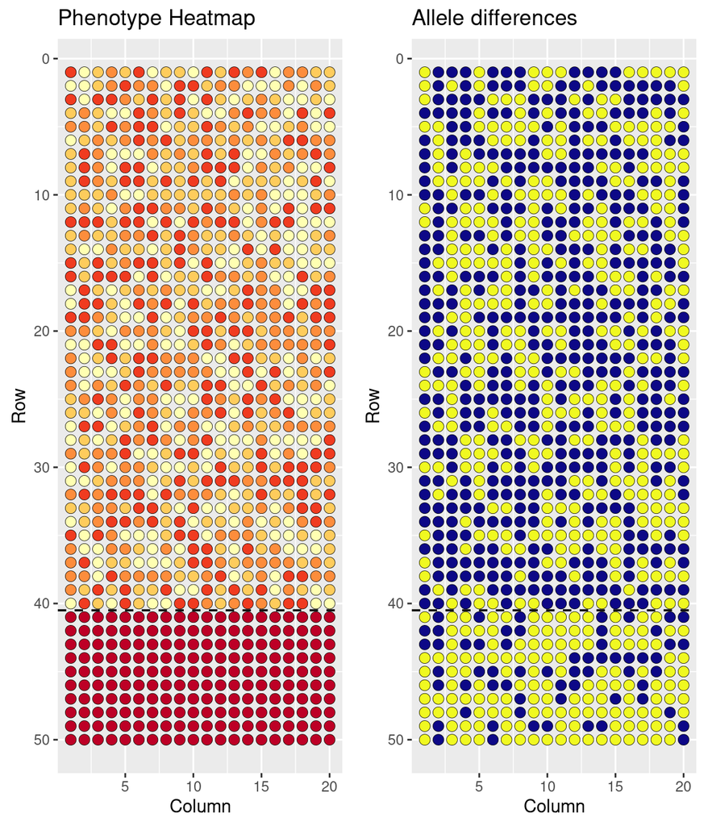

There are two key information in the plots:

1. There is clear phenotypic variation in fruit color across the field in the breeding zone.
2. The pre-breeding plants, located consistently at the ends of the rows, originate from a single genetic subgroup, while the breeding plants show different allele origins as presented in yellow.

These information can be summarized in the plots in the sequence.

- In the left-hand we have the allele frequency, and the breeding program has more diversity.
- In the right-hand we show that that is a clear connection between the phenotypic value (color of the berries), with the origin (elite to wild).

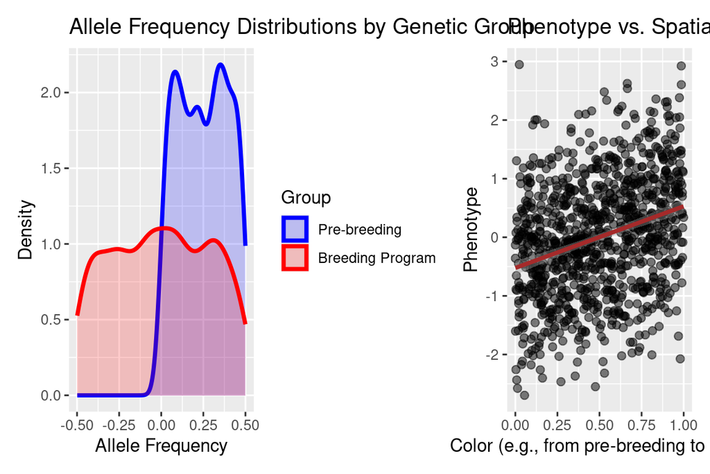

In summary, we simulated two population with different allele frequency and genotypic variation associated to the population origin. With that, the central question is: **how this confounding between population structure, allele frequencies and phenotypic variation will affect the GWAS results?**

To test it, we will follow this trend:

- Trial 1 :Run a regular GWAS and report the QQplot
- Trial 2: Simulate a QTL, run the GWAS, and report the QQplot
- Trial 3: Simulate a QTL, run the GWAS corrected by population structure, and report the QQplot

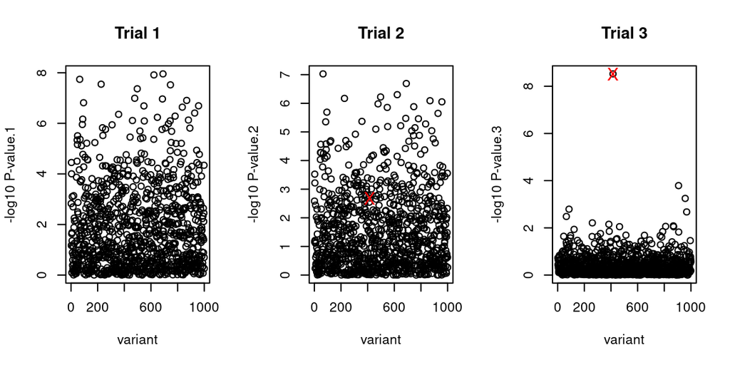

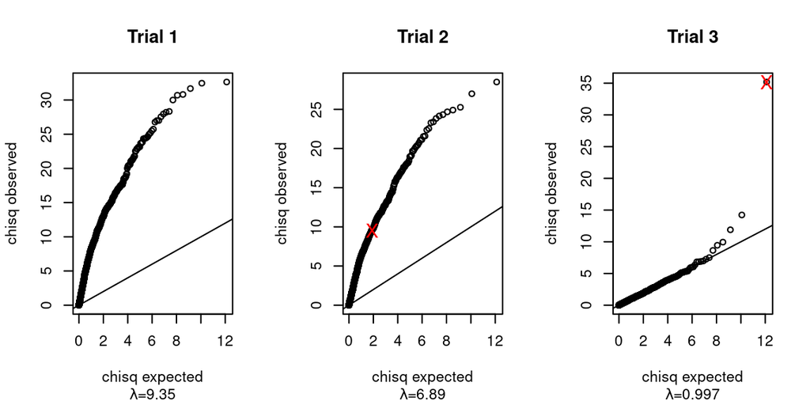

**Conclusions**

- The use of naive models, ignoring population structure, inflated all the p.values.
- In the scenario of inflated p.values, it is not clear where is the causal SNP.
- Ability to see the true effect after the confounding effect has been considered.

# Hands-on

## Simulated example

**Information**

- Script name: Performing association study with simulated population
- Authors: Jon Bancic, Philip Greenspoon, Chris Gaynor, Gregor Gorjanc
- Date Created: 2023-01-23
- This script demonstrates how to simulate a population for a GWAS study. The simulation starts off by creating a single homogeneous population which then undergoes a few rounds of selection to induce stratification.
- Scrip and analyses were inspired by this [link](https://github.com/HighlanderLab/jbancic_alphasimr_plants)
- Simulation will be performed using the `AlphaSim` software.

**Simulation**

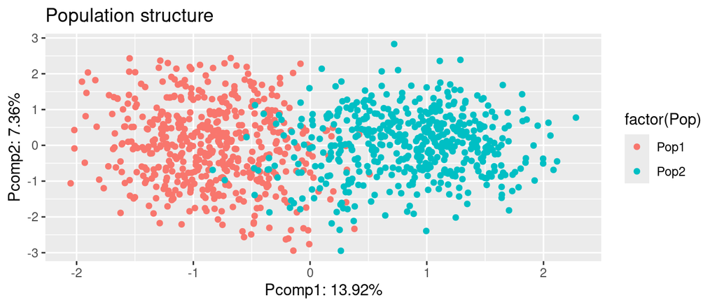

```r
set.seed(123)
# ---- Clean environment and load packages ----
rm(list = ls())
library(package = "AlphaSimR")
library(package = "ade4")
library(package = "ggplot2")
library(package = "rrBLUP")
library(package = "qqman")

# ---- Setup simulation ----

# Generate founder haplotypes
founderPop = runMacs(
  nInd     = 1000,
  nChr     = 10,
  segSites = 300,
  inbred   = FALSE,
  # split    = 100, # alternative way to split population
  species = "GENERIC"
)

# Set simulation parameters
SP = SimParam$new(founderPop)

# Force QTLs and SNPs to overlap
SP$restrSegSites(overlap = T)

# Create additive trait with 3 QTLs per chromosome
SP$addTraitAG(nQtlPerChr = 5, mean = 0, var  = 1)

# Add SNP-chip with 300 SNPs per chromosome
SP$addSnpChip(nSnpPerChr = 300)

# ---- Create two subpopulations ----
pop  = newPop(founderPop)
popA = pop[1:500]
popB = pop[501:1000]
# Few rounds of crossing and selection
# Alternatively, set split in runMaCS call and skip this
for (i in 1:5) {
  popA = selectCross(popA, nInd = 50, nCrosses = 100, nProgeny = 5, use = "gv")
  popB = selectCross(popB, nInd = 100, nCrosses = 500, use = "gv")
}
pop = c(popA, popB)
pop = setPheno(pop, h2 = 0.4)

# ---- Visualise two sub-populations with PCA ----
geno = pullQtlGeno(pop)
PCA  = dudi.pca(df = geno, center = T, scale = F, scannf = F, nf = 5)
VAF = 100 * PCA$eig[1:5] / sum(PCA$eig) # variance explained
df.PCA = data.frame(
  "Pop" = c(rep("Pop1", popA@nInd), rep("Pop2", popB@nInd)),
  "PC1" = PCA$l1$RS1,
  "PC2" = PCA$l1$RS2)

# Plot
ggplot(df.PCA, aes(x = PC1, y = PC2)) +
  geom_point(aes(colour = factor(Pop))) +
  ggtitle("Population structure") +
  xlab(paste("Pcomp1: ", round(VAF[1], 2), "%", sep = "")) +
  ylab(paste("Pcomp2: ", round(VAF[2], 2), "%", sep = ""))
```

```r
# ---- Run GWAS ----

# Prepare data
pheno  = data.frame(id     = 1:pop@nInd,
                    pheno  = pop@pheno,
                    subPop = factor(c(
                      rep("Pop1", popA@nInd),
                      rep("Pop2", popB@nInd)
                    )))
geno   = pullSnpGeno(pop)
geno   = data.frame(
  snp = colnames(geno),
  chr = rep(1:10, each = 300),
  pos = rep(1:300, 10),
  t(geno - 1)
)
colnames(geno)[-c(1:3)] = 1:pop@nInd

# Run three GWAS models
K.tmp = diag(1,1000)
rownames(K.tmp)<-pheno$id
colnames(K.tmp)<-pheno$id

model1 = GWAS(pheno[, -3], geno,K=K.tmp, plot = F)
```

```
## [1] "GWAS for trait: Trait1"
## [1] "Variance components estimated. Testing markers."
```

```r
model2 = GWAS(pheno[, -3], geno, n.PC = 3, plot = F)
```

```
## [1] "GWAS for trait: Trait1"
## [1] "Variance components estimated. Testing markers."
```

```r
model3 = GWAS(pheno,       geno, fixed = "subPop", plot = F)
```

```
## [1] "GWAS for trait: Trait1"
## [1] "Variance components estimated. Testing markers."
```

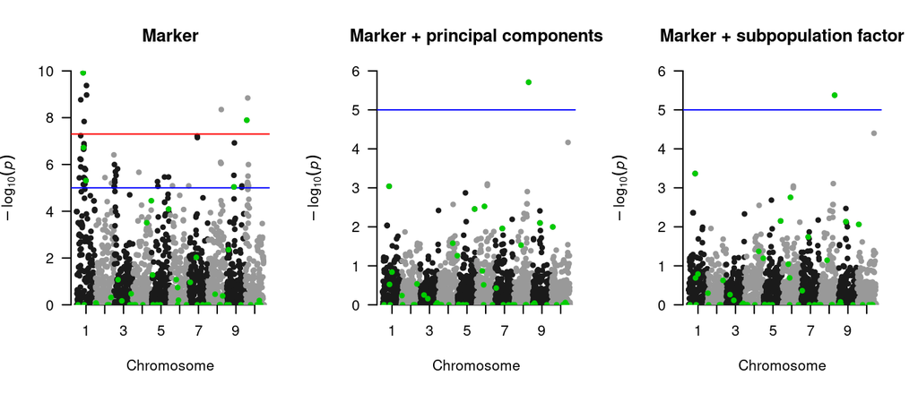

```r
# Obtain p values
model1$Trait1 = 10 ^ (-model1$Trait1)
model2$Trait1 = 10 ^ (-model2$Trait1)
model3$Trait1 = 10 ^ (-model3$Trait1)

# Get true positions of QTLs
qtl = as.vector(getQtlMap(trait = 1)$id)

# Check Manhattan plot
par(mfrow = c(1, 3))
manhattan(model1, chr = "chr", bp = "pos", p = "Trait1", snp = "snp", highlight = qtl,
          main = "Marker")
manhattan(model2, chr = "chr", bp = "pos", p = "Trait1", snp = "snp", highlight = qtl,
          main = "Marker + principal components")
manhattan(model3, chr = "chr", bp = "pos", p = "Trait1", snp = "snp", highlight = qtl,
          main = "Marker + subpopulation factor")
```

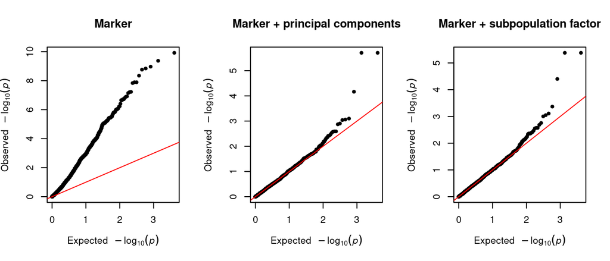

```r
# Check QQ-plot
par(mfrow = c(1, 3))
qq(model1$Trait1, main = "Marker")
qq(model2$Trait1, main = "Marker + principal components")
qq(model3$Trait1, main = "Marker + subpopulation factor")
```

# Conclusions

Correcting for **population structure** is critical in GWAS to avoid **spurious associations** and ensure the reliability of results. Population structure—differences in allele frequencies due to ancestry or subpopulation differentiation—can lead to false positives if not properly accounted for, as unrelated genetic variation may correlate with the trait of interest. To mitigate this, statistical models commonly include structure covariates (e.g., principal components) or kinship matrices to control for both **population stratification** and **relatedness** among individuals.

In the next classes, we will cover some formal methods such as the **mixed linear model (MLM)** and multi-locus approaches like **FarmCPU** or **MLMM** that effectively balance power and control of false positives by integrating both fixed effects (e.g., population structure) and random effects (e.g., kinship).

# References

- Price, A. L., Patterson, N. J., Plenge, R. M., Weinblatt, M. E., Shadick, N. A., & Reich, D. (2006). Principal components analysis corrects for stratification in genome-wide association studies. *Nature Genetics*, 38(8), 904–909. https://doi.org/10.1038/ng1847
- Yu, J., Pressoir, G., Briggs, W. H., Vroh Bi, I., Yamasaki, M., Doebley, J. F., McMullen, M. D., Gaut, B. S., Nielsen, D. M., Holland, J. B., Kresovich, S., & Buckler, E. S. (2006). A unified mixed-model method for association mapping that accounts for multiple levels of relatedness. *Nature Genetics*, 38(2), 203–208. https://doi.org/10.1038/ng1702
- Hickey, J. M., Gorjanc, G., Cleveland, M. A., & Hickey, K. R. (2014). AlphaSim: Software for breeding program simulation. *The Plant Genome*, 7(3), 1–10. https://doi.org/10.3835/plantgenome2013.11.0032